# Machine Learning Peer Project

Kim Kirk

May 14, 2018

# Supervised Machine Learning Classifier of Human Activity Recognition

## Model Selection and Creation

The data set is imported as are required packages. Seed is set for reproducibility.

```r
#import training data set
path <- file.path(paste(getwd(), 'pml-training.csv', sep = "/"))
url <- "https://d396qusza40orc.cloudfront.net/predmachlearn/pml-training.csv"
download.file(url, path)
trainingImport <- read.csv("pml-training.csv", header = TRUE, stringsAsFactors = FALSE)

##check environment for packages and install or not as required
##credit Matthew on StackOverflow https://stackoverflow.com/users/4125693/matthew
using<-function(...) {
    libs<-unlist(list(...))
    req<-unlist(lapply(libs,require,character.only=TRUE))
    need<-libs[req==FALSE]
    n<-length(need)
    if(n>0){
        libsmsg<-if(n>2) paste(paste(need[1:(n-1)],collapse=", "),",",sep="") else need[1]
        print(libsmsg)
        if(n>1){
            libsmsg<-paste(libsmsg," and ", need[n],sep="")
        }
        libsmsg<-paste("The following packages could not be found: ",libsmsg,"\n\r\n\rInstall missing packages?",collapse="")
        if(winDialog(type = c("yesno"), libsmsg)=="YES"){
            install.packages(need)
            lapply(need,require,character.only=TRUE)
        }
    }
}

##install and load packages
using("dplyr")
using("caret")
using("mlbench")
#set seed for reproducibility
set.seed(550)
```

## Detecting Issues in the Data Set

Redundant Predictor Variables

```r
#find and remove predictor variables that are not needed for predictive purposes
indexPositions <- grep("^kurtosis|skewness|max|min|amplitude|var|avg|stddev", colnames(trainingImport), value = FALSE)
trainingDataSet <- select(trainingImport, 1:160, -(indexPositions))
```

Outliers

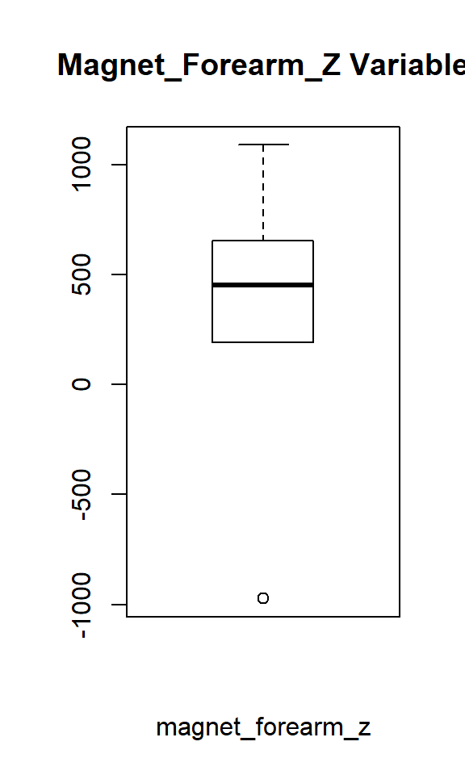

Outliers for two predictor variables

```r
boxplot(summary(trainingDataSet$magnet_forearm_z), main = "Magnet_Forearm_Z Variable", xlab = "magnet_forearm_z")
```

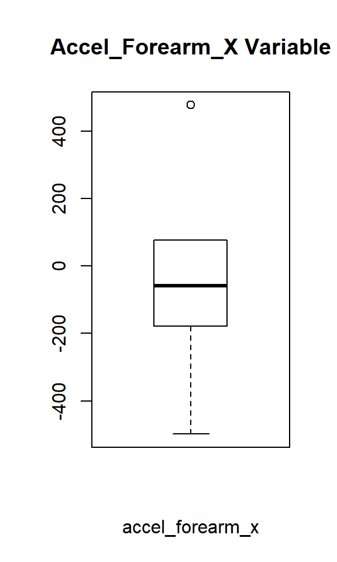

Outliers for two predictor variables

```r
boxplot(summary(trainingDataSet$accel_forearm_x), main = "Accel_Forearm_X Variable", xlab = "accel_forearm_x")
```

Variable Imbalance: See Appendix A

## Model Selection

Random Forest machine learning algorithm from the “caret” package is selected because it can handle issues found in the data set during the data exploration phase such as: - categorical nature of the outcome variable to create a classification model - mixed data types for predictor variables (quantitative and qualitative) without the requirement to create dummy variables or one-hot encoding - non-linear relationship between outcome and predictor variables - multiclass nature of the outcome variable - no assumption of normality of the predictor variables is required - increased interpretability for quantitative predictor variables that could not be transformed with a BoxCox or Log transformation - apply binning to imbalanced data

```r
#find and remove correlated predictor variables to reduce redundancy and improve prediction
correlationMatrix <- cor(trainingDataSet[,-c(1, 2, 5, 6, 60)])
highlyCorrelated <- findCorrelation(correlationMatrix, cutoff=0.5, names = TRUE)
print(highlyCorrelated)
```

```
##  [1] "accel_belt_z"         "roll_belt"            "accel_belt_y"
##  [4] "accel_arm_y"          "total_accel_belt"     "yaw_belt"
##  [7] "accel_dumbbell_z"     "accel_belt_x"         "magnet_belt_x"
## [10] "pitch_belt"           "yaw_dumbbell"         "magnet_dumbbell_x"
## [13] "accel_dumbbell_y"     "magnet_dumbbell_y"    "total_accel_dumbbell"
## [16] "magnet_dumbbell_z"    "accel_forearm_x"      "accel_arm_x"
## [19] "raw_timestamp_part_1" "accel_dumbbell_x"     "magnet_forearm_z"
## [22] "accel_arm_z"          "magnet_arm_y"         "magnet_belt_y"
## [25] "accel_forearm_y"      "magnet_arm_x"         "pitch_arm"
## [28] "gyros_dumbbell_y"     "gyros_forearm_z"      "gyros_forearm_y"
## [31] "gyros_dumbbell_z"     "gyros_arm_x"
```

```r
trainingDataSet <- select(trainingDataSet, -one_of(highlyCorrelated))

#remove predictor variable that is not needed for predictive purposes
trainingDataSet <- trainingDataSet[,-(1)]

#transform outcome variable
trainingDataSet$classe <- as.factor(trainingDataSet$classe)

#tune parameters for resampling/validation purposes
ctrl = trainControl(method="cv", number = 3, selectionFunction = "oneSE")

#partition training data into training and validation data sets
inTraining <- createDataPartition(trainingDataSet$classe, p = .75, list = FALSE)
    training <- trainingDataSet[ inTraining,]
    testing  <- trainingDataSet[-inTraining,]

#train the model
trained <- train(classe ~ .,
                     data = training, method = "rf",
                     trControl = ctrl, metric = "Accuracy",
                     preProcess = c("center", "scale"))

#make predictions using validation data set
predicted <- predict(trained, newdata = testing, type = "raw")
```

## Cross Validation and Expected Out-of-Sample Error Rate

- Cross validation with 3 folds is used with a selection function of oneSE because the tuning parameter associated with the best performance may over fit; the simplest model within one standard error of the empirically optimal model is the better choice [Breiman et al.(1984)].
- The accuracy rate, which is overall how often the classifier is correct, is 99.84% which is high.
- The expected out-of-sample error rate is 0.16% which is low.

```r
#check accuracy of model
confusionMatrix <- confusionMatrix(predicted, testing[,27], mode = "everything")
confusionMatrix
```

```
## Confusion Matrix and Statistics
##
##           Reference
## Prediction    A    B    C    D    E
##          A 1395    0    0    0    0
##          B    0  945    0    0    0
##          C    0    4  854    3    0
##          D    0    0    1  801    0
##          E    0    0    0    0  901
##
## Overall Statistics
##
##                Accuracy : 0.9984
##                  95% CI : (0.9968, 0.9993)
##     No Information Rate : 0.2845
##     P-Value [Acc > NIR] : < 2.2e-16
##
##                   Kappa : 0.9979
##  Mcnemar's Test P-Value : NA
##
## Statistics by Class:
##
##                      Class: A Class: B Class: C Class: D Class: E
## Sensitivity            1.0000   0.9958   0.9988   0.9963   1.0000
## Specificity            1.0000   1.0000   0.9983   0.9998   1.0000
## Pos Pred Value         1.0000   1.0000   0.9919   0.9988   1.0000
## Neg Pred Value         1.0000   0.9990   0.9998   0.9993   1.0000
## Precision              1.0000   1.0000   0.9919   0.9988   1.0000
## Recall                 1.0000   0.9958   0.9988   0.9963   1.0000
## F1                     1.0000   0.9979   0.9953   0.9975   1.0000
## Prevalence             0.2845   0.1935   0.1743   0.1639   0.1837
## Detection Rate         0.2845   0.1927   0.1741   0.1633   0.1837
## Detection Prevalence   0.2845   0.1927   0.1756   0.1635   0.1837
## Balanced Accuracy      1.0000   0.9979   0.9986   0.9980   1.0000
```

# Appendix A

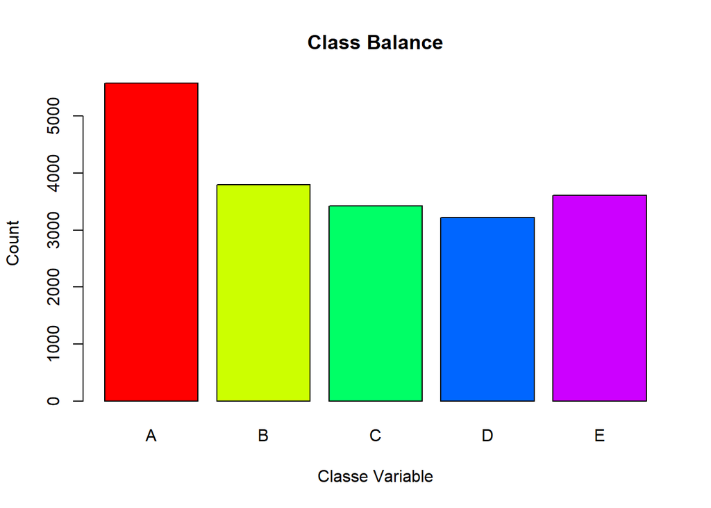

```r
barplot(table(trainingDataSet$classe), main = "Class Balance", xlab = "Classe Variable", ylab = "Count", col = rainbow(5))
```